# County Level Relationships Between Poverty and Adverse Health Conditions

Author

Breanna Post, Asmaa Elsayed, Nailah Gayle

Published

February 18, 2026

# Introduction:

For our group project, we wanted to see if places that have more barriers to getting healthy food also tend to have worse health outcomes. At first we were trying to measure food deserts, but it ended up being kinda hard to make one clean county-level food desert variable that matched well with our health data. The usda data is super detailed at the census tract level, but the cdc places data we used is county level, and it only had the measures we needed in 2023. So to keep the join simple and not make too many assumptions, we focused this deliverable on something more consistent: county level poverty from the usda data (summarized up from tracts) and county level health outcomes from cdc places (obesity and diabetes). This lets us start by looking for basic patterns between poverty and these outcomes, and it gives us a solid joined dataset we can build on for the later parts of the project.

**Project Focus**

• Food accessibility  
• Health equity  
• County-level poverty  
• Obesity & diabetes patterns

# Section I: USDA census

### I.1 Data source:

**Dataset:** USDA Economic Research Service (ERS) Food Access Research Atlas (2019 release).

**Link:** https://www.ers.usda.gov/data-products/food-access-research-atlas

Our first dataset comes from the USDA food access research atlas in 2019. It is a public federal dataset that measures food access and related census-tract conditions across the United States, including poverty, income, vehicle access, and low-income or low-access indicators.

### I.2 Data meaning

This dataset shows census-tract level conditions that can make it easier or harder for people to access healthy food. It matters for our project because food access, along with factors like income and vehicle access, can connect to health outcomes like obesity and diabetes, which we will pull from our second dataset

### I.3 Data observations

```r
usda_food <- read_excel("FoodAccessResearchAtlasData2019 (2).xlsx", sheet = 1)

glimpse(usda_food)
```

```
Rows: 72,531
Columns: 147
$ CensusTract          <chr> "01001020100", "01001020200", "01001020300", "010…
$ State                <chr> "Alabama", "Alabama", "Alabama", "Alabama", "Alab…
$ County               <chr> "Autauga County", "Autauga County", "Autauga Coun…
$ Urban                <dbl> 1, 1, 1, 1, 1, 1, 1, 0, 0, 0, 0, 0, 0, 0, 0, 0, 1…
$ Pop2010              <dbl> 1912, 2170, 3373, 4386, 10766, 3668, 2891, 3081, …
$ OHU2010              <dbl> 693, 743, 1256, 1722, 4082, 1311, 1188, 1074, 369…
$ GroupQuartersFlag    <dbl> 0, 0, 0, 0, 0, 0, 0, 0, 0, 0, 0, 0, 0, 0, 0, 0, 0…
$ NUMGQTRS             <dbl> 0, 181, 0, 0, 181, 0, 36, 0, 0, 14, 10, 33, 31, 6…
$ PCTGQTRS             <dbl> 0.00000000, 8.34101382, 0.00000000, 0.00000000, 1…
$ LILATracts_1And10    <dbl> 0, 1, 0, 0, 0, 1, 1, 0, 0, 0, 1, 1, 1, 0, 0, 0, 0…
$ LILATracts_halfAnd10 <dbl> 0, 1, 0, 0, 0, 1, 1, 0, 0, 0, 1, 1, 1, 0, 0, 0, 0…
$ LILATracts_1And20    <dbl> 0, 1, 0, 0, 0, 1, 1, 0, 0, 0, 0, 0, 0, 0, 0, 0, 0…
$ LILATracts_Vehicle   <dbl> 0, 0, 0, 0, 0, 0, 0, 0, 0, 0, 0, 1, 0, 0, 0, 0, 0…
```

[output cut: 134 more lines]

After loading the USDA Food Access dataset, I used glimpse() to check whats in the data. The dataset has 72,531 rows and 147 columns. Each row represents a U.S. census tract, identified by CensusTract.

### I.4 Data Issues

**Checking for NULLS**

```r
usda_food |>
  summarize(
    n_rows = n(),
    null_income = sum(MedianFamilyIncome == "NULL", na.rm = TRUE),
    na_income = sum(is.na(MedianFamilyIncome))
  )
```

```
# A tibble: 1 × 3
  n_rows null_income na_income
   <int>       <int>     <int>
1  72531         748         0
```

**Removing Nulls**

```r
usda_clean <- usda_food |>
  mutate(
    CensusTract = as.character(CensusTract),
    MedianFamilyIncome = na_if(MedianFamilyIncome, "NULL"),
    MedianFamilyIncome = as.numeric(MedianFamilyIncome)
  )


usda_clean |>
  summarize(
    na_income_after = sum(is.na(MedianFamilyIncome))
  )
```

```
# A tibble: 1 × 1
  na_income_after
            <int>
1             748
```

When I loaded the USDA dataset, I got a bunch of warnings because some columns contain the value null in places where numbers should be. In medianfamilyincome, there were 748 null entries out of 72,531 rows. To fix it, I changed NULL values into NA and then converted MedianFamilyIncome into a numeric column.

# Section 2: CDC places

### II.1 Data Source

Link: https://www.cdc.gov/places/

Our second dataset comes from the CDC PLACES program. It is a public health dataset that provides county-level estimates for many health measures across the United States, based on BRFSS survey data and CDC modeling methods. We are using it because it includes outcomes like obesity and diagnosed diabetes that we can compare with food access indicators from the USDA dataset.

### II.2 Data meaning

This dataset provides county level estimates for health outcomes and risk factors, reported as percentages for specific measures. It matters for our project because it includes outcomes like obesity and diagnosed diabetes, which we can compare with food access and socioeconomic indicators from the USDA dataset to look for patterns between access to healthy food and health at the local level.

### II.3 Data observations

```r
cdc_places <-
  read_csv("PLACES__Local_Data_for_Better_Health,_County_Data,_2025_release_20260213.csv")
glimpse(cdc_places)
```

```
Rows: 229,298
Columns: 22
$ Year                       <dbl> 2023, 2023, 2023, 2023, 2023, 2023, 2023, 2…
$ StateAbbr                  <chr> "AR", "AR", "AR", "AR", "AR", "AR", "AR", "…
$ StateDesc                  <chr> "Arkansas", "Arkansas", "Arkansas", "Arkans…
$ LocationName               <chr> "Drew", "Fulton", "Howard", "Miller", "Ouac…
$ DataSource                 <chr> "BRFSS", "BRFSS", "BRFSS", "BRFSS", "BRFSS"…
$ Category                   <chr> "Health Outcomes", "Health Outcomes", "Heal…
$ Measure                    <chr> "Arthritis among adults", "Current asthma a…
$ Data_Value_Unit            <chr> "%", "%", "%", "%", "%", "%", "%", "%", "%"…
$ Data_Value_Type            <chr> "Crude prevalence", "Crude prevalence", "Cr…
$ Data_Value                 <dbl> 29.9, 10.6, 31.2, 4.7, 42.8, 3.9, 5.4, 27.5…
$ Data_Value_Footnote_Symbol <chr> NA, NA, NA, NA, NA, NA, NA, NA, NA, NA, NA,…
$ Data_Value_Footnote        <chr> NA, NA, NA, NA, NA, NA, NA, NA, NA, NA, NA,…
$ Low_Confidence_Limit       <dbl> 26.6, 9.2, 27.7, 4.2, 37.9, 3.4, 4.7, 23.2,…
$ High_Confidence_Limit      <dbl> 33.3, 11.9, 34.8, 5.3, 47.8, 4.3, 6.2, 32.0…
$ TotalPopulation            <dbl> 16945, 12421, 12533, 42415, 21793, 400009, …
$ TotalPop18plus             <dbl> 13230, 9795, 9311, 32396, 16948, 307397, 13…
$ LocationID                 <chr> "05043", "05049", "05061", "05091", "05103"…
$ CategoryID                 <chr> "HLTHOUT", "HLTHOUT", "HLTHOUT", "HLTHOUT",…
$ MeasureId                  <chr> "ARTHRITIS", "CASTHMA", "ARTHRITIS", "STROK…
$ DataValueTypeID            <chr> "CrdPrv", "CrdPrv", "CrdPrv", "CrdPrv", "Cr…
$ Short_Question_Text        <chr> "Arthritis", "Current Asthma", "Arthritis",…
$ Geolocation                <chr> "POINT (-91.7196579038053 33.5894113647675)…
```

After loading the cdc_places dataset, I used glimpse to check its structure. The dataset has 229,298 rows and 22 columns. Each row represents a health measure for a specific place and year.

### II.4 Data Join

The join will use a county ID. In cdc_places, the county code is LocationID. In the USDA data, the main ID is CensusTract, so it does not match LocationID exactly. CensusTract is an 11 digit code, where the first 2 digits are the state, the next 3 digits are the county, and the last 6 digits are the tract, and LocationID is the same except without the 6 digit tract code. Because of that, we can take the first 5 digits of CensusTract to get the county code, then join that to LocationID. We will use a left_join so we keep all USDA rows and only add PLACES values when they exist..

### II.5 Data Issues

**Find missing values**

```r
cdc_places |>
  summarize(
    n_rows = n(),
    missing_value = sum(is.na(Data_Value))
  )
```

```
# A tibble: 1 × 2
  n_rows missing_value
   <int>         <int>
1 229298            66
```

**See how many years and measures are in the data**

```r
cdc_places |>
  summarize(
    n_years = n_distinct(Year),
    n_measures = n_distinct(Measure)
  )
```

```
# A tibble: 1 × 2
  n_years n_measures
    <int>      <int>
1       2         40
```

The cdc_places dataset is not ready to join as-is because it includes many different health measures and more than one year. In this file there are 229,298 rows and 66 rows have missing values in Data_Value. The dataset includes 2 years of data and 40 different measures. Since we only need a couple measures for our project, we will filter the dataset to the outcomes we care about and choose one year so we do not create duplicates when we join.

# Section 3: Joining

### III.1 Changes

Before joining, we made a few changes so the two datasets would work together. We kept CensusTract as a character column so it keeps leading zeros, and we cleaned MedianFamilyIncome by turning null into na and converting it to numeric. Because the USDA data is tract level and the places file is county level, we created a new county_ID by taking the first five digits of CensusTract. We then summarized the USDA tract data up to the county level. For the PLACES data, we filtered to the year 2023 and only kept the two measures we care about, obesity and diabetes . We also filtered to one value type so we would not get duplicate values when we reshaped the data. Finally, we pivoted places from long format to wide format so each county appears once with obesity and diabetes as columns.

### III.2 Prepare USDA for join

**Make county_ID from only keeping the first 5 digits of CensusTract**

```r
usda_county <- usda_clean |>
  mutate(
    county_ID = str_sub(CensusTract, 1, 5)
  )
```

**Get the averages of each poverty indicator in usda_county**

```r
usda_county_summary <- usda_county |>
  group_by(county_ID) |>
  summarize(
    tracts = n(),
    avg_poverty = mean(PovertyRate, na.rm = TRUE),
    avg_income = mean(MedianFamilyIncome, na.rm = TRUE),
    pct_low_income_tracts = mean(LowIncomeTracts, na.rm = TRUE) * 100,
    pct_lila_1and10 = mean(LILATracts_1And10, na.rm = TRUE) * 100,
    pct_lila_vehicle = mean(LILATracts_Vehicle, na.rm = TRUE) * 100,
    .groups = "drop"
  )

glimpse(usda_county_summary)
```

```
Rows: 3,142
Columns: 7
$ county_ID             <chr> "01001", "01003", "01005", "01007", "01009", "01…
$ tracts                <int> 12, 31, 9, 4, 9, 3, 9, 30, 9, 6, 9, 4, 9, 4, 4, …
$ avg_poverty           <dbl> 16.13079, 11.84555, 29.29932, 12.19352, 14.85075…
$ avg_income            <dbl> 69337.50, 72665.74, 44792.44, 60645.50, 60437.67…
$ pct_low_income_tracts <dbl> 41.66667, 22.58065, 88.88889, 25.00000, 33.33333…
$ pct_lila_1and10       <dbl> 41.666667, 12.903226, 44.444444, 0.000000, 0.000…
$ pct_lila_vehicle      <dbl> 8.333333, 9.677419, 33.333333, 25.000000, 22.222…
```

The USDA dataset is at the census tract level, but our CDC dataset is at the county level, so we cannot join them directly. To fix this, we created county_ID from CensusTract by taking the first five digits, which represent the county code. Then we grouped by county_ID and summarized the USDA variables so we have one row per county. This gives us county level averages and percentages that we can compare to county health outcomes in CDC.

### III.3 Prepare cdc_places for the join

**Filter by year (2023) and measure ID (only diabetes and obesity with their prevalence values). Then selected the other variables we needed.**

```r
places_small <- cdc_places |>
  filter(
    Year == 2023,
    MeasureId %in% c("OBESITY", "DIABETES"),
    Data_Value_Type == "Crude prevalence" ) |>
  select(LocationID, LocationName, StateAbbr, StateDesc, MeasureId, Data_Value)


glimpse(places_small)
```

```
Rows: 5,916
Columns: 6
$ LocationID   <chr> "08125", "12009", "12017", "13225", "13289", "17031", "19…
$ LocationName <chr> "Yuma", "Brevard", "Citrus", "Peach", "Twiggs", "Cook", "…
$ StateAbbr    <chr> "CO", "FL", "FL", "GA", "GA", "IL", "IA", "KS", "KS", "MN…
$ StateDesc    <chr> "Colorado", "Florida", "Florida", "Georgia", "Georgia", "…
$ MeasureId    <chr> "OBESITY", "DIABETES", "DIABETES", "OBESITY", "OBESITY", …
$ Data_Value   <dbl> 28.4, 13.1, 15.8, 39.3, 39.7, 31.0, 40.2, 13.2, 35.1, 9.4…
```

**Then change measure ID and Datavalues from a row into a column**

```r
places_wide <- places_small |>
  pivot_wider(names_from = MeasureId, values_from = Data_Value)

glimpse(places_wide)
```

```
Rows: 2,958
Columns: 6
$ LocationID   <chr> "08125", "12009", "12017", "13225", "13289", "17031", "19…
$ LocationName <chr> "Yuma", "Brevard", "Citrus", "Peach", "Twiggs", "Cook", "…
$ StateAbbr    <chr> "CO", "FL", "FL", "GA", "GA", "IL", "IA", "KS", "KS", "MN…
$ StateDesc    <chr> "Colorado", "Florida", "Florida", "Georgia", "Georgia", "…
$ OBESITY      <dbl> 28.4, 34.0, 32.3, 39.3, 39.7, 31.0, 40.2, 41.8, 35.1, 33.…
$ DIABETES     <dbl> 10.9, 13.1, 15.8, 14.9, 18.6, 11.8, 13.6, 13.2, 11.5, 9.4…
```

The cdc_places dataset includes many measures and more than one year, so we filtered it before joining. We kept only the year 2023 and only the two measures we need, obesity and diabetes, then selected the other varibles we needed. We also filtered to datavalue type to crude prevalence so each county and measure has a single value. After filtering, the data was still in long format, meaning obesity and diabetes were stored as rows under MeasureId. We used pivot_wider to reshape the data so each county appears once, with separate columns for obesity and diabetes.

### III.4 Join the datasets

```r
joined_df <- usda_county_summary |>
  left_join(places_wide, join_by(county_ID == LocationID))

glimpse(joined_df)
```

```
Rows: 3,142
Columns: 12
$ county_ID             <chr> "01001", "01003", "01005", "01007", "01009", "01…
$ tracts                <int> 12, 31, 9, 4, 9, 3, 9, 30, 9, 6, 9, 4, 9, 4, 4, …
$ avg_poverty           <dbl> 16.13079, 11.84555, 29.29932, 12.19352, 14.85075…
$ avg_income            <dbl> 69337.50, 72665.74, 44792.44, 60645.50, 60437.67…
$ pct_low_income_tracts <dbl> 41.66667, 22.58065, 88.88889, 25.00000, 33.33333…
$ pct_lila_1and10       <dbl> 41.666667, 12.903226, 44.444444, 0.000000, 0.000…
$ pct_lila_vehicle      <dbl> 8.333333, 9.677419, 33.333333, 25.000000, 22.222…
$ LocationName          <chr> "Autauga", "Baldwin", "Barbour", "Bibb", "Blount…
$ StateAbbr             <chr> "AL", "AL", "AL", "AL", "AL", "AL", "AL", "AL", …
$ StateDesc             <chr> "Alabama", "Alabama", "Alabama", "Alabama", "Ala…
$ OBESITY               <dbl> 39.8, 35.2, 46.8, 43.9, 36.1, 51.3, 40.4, 38.6, …
$ DIABETES              <dbl> 13.3, 13.4, 19.6, 16.2, 13.8, 24.6, 18.9, 14.8, …
```

```r
nrow(joined_df)
```

```
[1] 3142
```

```r
ncol(joined_df)
```

```
[1] 12
```

We joined the two datasets using county_ID from the USDA county summary and LocationID from places_wide. We used a left_join so we kept all counties from the USDA side and only added PLACES values when a match existed. After joining, the combined dataset has 3,142 rows, with one row per county. It includes the USDA county summary variables plus the PLACES health outcome columns obesity and diabetes.

### III.6 Codebooks / column documentation links

- USDA Food Access Research Atlas variable list (codebook PDF): https://www.ers.usda.gov/sites/default/files/images/variablelist_gc.pdf
- CDC PLACES data dictionary: https://data.cdc.gov/500-Cities-Places/PLACES-and-500-Cities-Data-Dictionary/m35w-spkz

**The most important variables we plan to use**:

- obesity (CDC PLACES): adult obesity prevalence estimate (percent)
- diabetes (CDC PLACES): diagnosed diabetes prevalence estimate (percent)
- avg_poverty (USDA): average tract poverty rate, summarized to county level
- avg_income (USDA): average median family income, summarized to county level
- pct_low_income_tracts (USDA): percent of tracts flagged as low income inside a county

### III.7 Data Bias

Our combined dataset has a few limits that could create bias. The USDA data starts at the census tract level, but we summarized it to the county level, which can hide differences inside a county. For example, some tracts might have much higher poverty , but the county average smooths that out and we can miss those pockets. The PLACES numbers are also estimates made from survey data and modeling, not direct medical records, so there’s some uncertainty. A small number of counties are missing values too. Also, the timing doesn’t line up perfectly: the USDA Food Access dataset we used is a 2019 release, while the CDC PLACES data we used is from 2023. Between those years, COVID-19 changed a lot, like jobs, income, and health behaviors, and many places saw higher prices and economic stress. Because of that, some counties could look “mismatched” since we’re comparing older conditions with newer health estimates, so this is more exploratory and not a perfect match.

For human rights principles, privacy risk is low because the data is aggregated, so no personal names or addresses. Accountability and transparency come from clearly explaining where the data came from and what we did to clean and join it. Fairness and nondiscrimination are still concerns because missing context or averaging can hide differences for some groups. Human control of technology and professional responsibility matter because we should not treat these patterns like they prove cause and effect. Promotion of human values means using the results to understand barriers and support healthier communities, not to place blame people or counties or use that data for things like pricing health insurance.

# Section 4: Data Wrangling

### IV.1 Clean column types

**Make sure Obesity and Diabetes values are treated as numeric values**

```r
joined_clean <- joined_df |>
  mutate(
    OBESITY = as.numeric(OBESITY),
    DIABETES = as.numeric(DIABETES)
  )

glimpse(joined_clean)
```

```
Rows: 3,142
Columns: 12
$ county_ID             <chr> "01001", "01003", "01005", "01007", "01009", "01…
$ tracts                <int> 12, 31, 9, 4, 9, 3, 9, 30, 9, 6, 9, 4, 9, 4, 4, …
$ avg_poverty           <dbl> 16.13079, 11.84555, 29.29932, 12.19352, 14.85075…
$ avg_income            <dbl> 69337.50, 72665.74, 44792.44, 60645.50, 60437.67…
$ pct_low_income_tracts <dbl> 41.66667, 22.58065, 88.88889, 25.00000, 33.33333…
$ pct_lila_1and10       <dbl> 41.666667, 12.903226, 44.444444, 0.000000, 0.000…
$ pct_lila_vehicle      <dbl> 8.333333, 9.677419, 33.333333, 25.000000, 22.222…
$ LocationName          <chr> "Autauga", "Baldwin", "Barbour", "Bibb", "Blount…
$ StateAbbr             <chr> "AL", "AL", "AL", "AL", "AL", "AL", "AL", "AL", …
$ StateDesc             <chr> "Alabama", "Alabama", "Alabama", "Alabama", "Ala…
$ OBESITY               <dbl> 39.8, 35.2, 46.8, 43.9, 36.1, 51.3, 40.4, 38.6, …
$ DIABETES              <dbl> 13.3, 13.4, 19.6, 16.2, 13.8, 24.6, 18.9, 14.8, …
```

**Check for missing values**

```r
joined_clean |>
  summarize(
    missing_obesity = sum(is.na(OBESITY)),
    missing_diabetes = sum(is.na(DIABETES))
  )
```

```
# A tibble: 1 × 2
  missing_obesity missing_diabetes
            <int>            <int>
1             197              197
```

### IV.2 Clean rows

**Remove na values**

```r
joined_health <- joined_clean |>
  filter(!(is.na(OBESITY) & is.na(DIABETES)))
```

We removed counties that were missing both outcomes because they cannot help with comparisons between poverty level and health outcomes.

### IV.3 Create poverty groups

**We created poverty groups to make it easier to compare patterns across low, mid, and high poverty counties.**

```r
joined_health <- joined_health |>
  mutate(
    poverty_group = case_when(
      avg_poverty >= 20 ~ "High poverty (20%+)",
      avg_poverty >= 10 ~ "Mid poverty (10-19.9%)",
      TRUE ~ "Lower poverty (<10%)"
    ))


joined_health |> count(poverty_group)
```

```
# A tibble: 3 × 2
  poverty_group              n
  <chr>                  <int>
1 High poverty (20%+)      646
2 Lower poverty (<10%)     541
3 Mid poverty (10-19.9%)  1758
```

### IV.4 Create group avg

**Find the averages of each variable, which helps summarizes the outcomes by the poverty groups we created.**

```r
summary_by_poverty <- joined_health |>
  group_by(poverty_group) |>
  summarize(
    counties = n(),
    avg_obesity = mean(OBESITY, na.rm = TRUE),
    avg_diabetes = mean(DIABETES, na.rm = TRUE),
    avg_income = mean(avg_income, na.rm = TRUE),
    avg_lila_vehicle = mean(pct_lila_vehicle, na.rm = TRUE),
    .groups = "drop"
  )

glimpse(summary_by_poverty)
```

```
Rows: 3
Columns: 6
$ poverty_group    <chr> "High poverty (20%+)", "Lower poverty (<10%)", "Mid p…
$ counties         <int> 646, 541, 1758
$ avg_obesity      <dbl> 40.43251, 35.05767, 37.08800
$ avg_diabetes     <dbl> 16.28359, 11.70111, 13.28441
$ avg_income       <dbl> 49752.57, 82452.72, 63841.14
$ avg_lila_vehicle <dbl> 35.643384, 3.369304, 13.855008
```

### IV.5 Graphs

#### IV.5A Graph Obesity vs. poverty

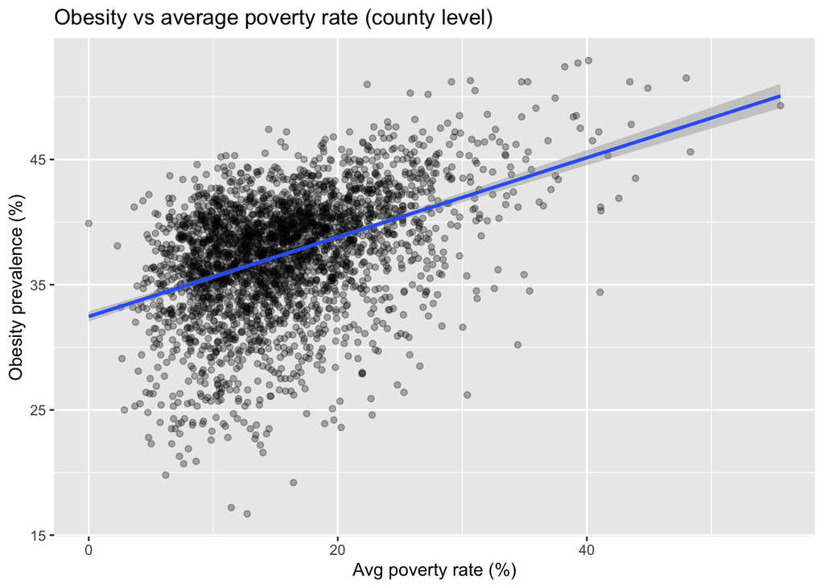

This graph shows the relationship between average poverty rate and obesity. Each dot is one county. The line goes up, which means counties with higher poverty rates usually have higher obesity percentages. The dots are still spread out, so it is not a perfect pattern, but there is a clear overall trend.

#### IV.5B Graph diabetes vs. poverty

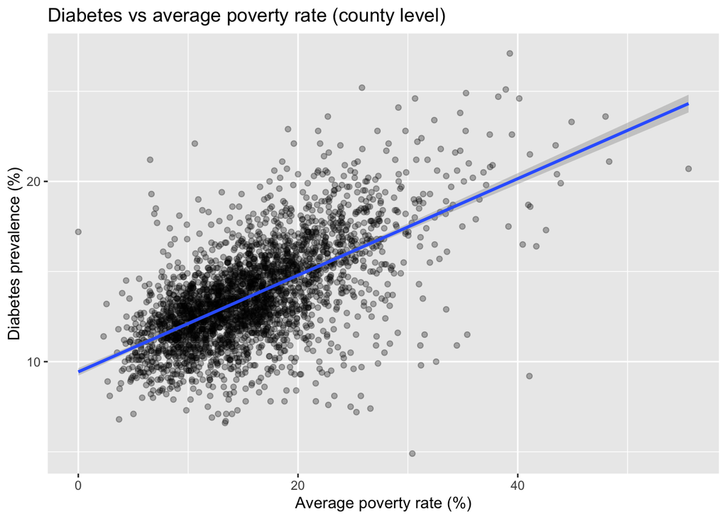

This graph shows the relationship between average poverty rate and diabetes. Each dot is one county. The line goes up here too, which means counties with higher poverty rates usually have higher diabetes percentages. There is still a bunch of variation, but the main trend is upward.

# Section 5: Group Information

### V.1 Team overview

Our group is researching how access to food and economic conditions connect to health outcomes like obesity and diabetes in different U.S. counties.  
We joined USDA and CDC datasets to look for patterns and better understand how poverty and access to resources might affect public health.

**Lab Details**  
• Lab Section: BA — Tuesday 12:30pm  
• TA: Yashita Tanwar

### V.2 Team members

**Breanna Post:**

My name is Breanna Post (Student at The University of Washington bpost411@uw.edu majoring in Psychology with a minor in Infomatics) I’m interested in the relationship with adverse health outcome and poverty rate because I think finding a correlation could better help get targeted resources to areas that need it the most. I plan to go apply to graduate school at the Evans School of Public Policy and one day use data to make informed decisions to help people.

**Asmaa Elsayed:**

My name is Asmaa Elsayed, and I am a student at the University of Washington studying Informatics at the Information School (Asmaael@uw.edu). I am interested in food accessibility and health equity, and I enjoy using design, visual storytelling, and data visualization to communicate complex information in a clear and meaningful way. Through this project, I focus on translating data into visuals that help people better understand real community challenges. I’m especially interested in how thoughtful design choices can make data more accessible, engaging, and easier for different audiences to connect with.

**Nailah Gayle:**

My name is Nailah Gayle (Student at the University of Washington ngayle9@uw.edu majoring in Art History and Informatics) I believe that as a double degree student, exploring the crossovers of virtual and physical communication can aid in widening access to resources and information across regions. I am passionate about sustainable public programming, peer-to-peer education, and fostering environments conducive to mentorship and tangible solutions to problems such as food insecurity.

### V.3 Coding Notes:

Most of our code uses tools from class, like filter, select, mutate, group_by, summarize, left_join, and ggplot. We did use a few tools that were not clearly shown in the lecture slides. We used readxl and read_excel to load the USDA dataset because it was an Excel file. We had to change NULL to NA for a column that was numeric. We used pivot_wider to reshape the CDC PLACES data from long format into wide format so OBESITY and DIABETES became columns. We used str_sub to create county_ID by taking the first five digits of CensusTract so it would match LocationID in PLACES. We used case_when to create a poverty_group category. One group member has taken INFO 180 and SOC 225 and completed the MSSA (Microsoft Systems and Software Academy) program for program managers, where they learned R basics, data cleaning, SQL/T-SQL, and Python, plus how to build dashboards in Excel and Power BI. That background helped with troubleshooting, organizing the workflow, and understanding how to clean and join data.

AI Statement: We used AI tools such as ChatGPT and Gemini for brainstorming, wording support, and minor troubleshooting, while all analysis decisions, coding, and final writing were completed and reviewed by our team.